# Risk Factor Analysis

## Outcome Variable

**Outcome Variable:** wasted

## Predictor Variables

**Intervention Variable:** feducyrs

**Adjustment Set:**

- arm
- W_mage
- meducyrs
- hhwealth_quart
- W_mhtcm
- W_gagebrth
- W_birthwt
- W_birthlen
- W_nrooms
- impfloor
- impsan
- safeh20
- delta_W_mage
- delta_meducyrs
- delta_hhwealth_quart
- delta_W_mhtcm
- delta_W_gagebrth
- delta_W_birthwt
- delta_W_birthlen
- delta_W_nrooms
- delta_impfloor
- delta_impsan
- delta_safeh20

## Stratifying Variables

The analysis was stratified on these variable(s):

- agecat
- studyid
- country

## Data Summary

| agecat | studyid | country | feducyrs | wasted | n_cell | n |
| --- | --- | --- | --- | --- | --- | --- |
| Birth | ki0047075b-MAL-ED | BANGLADESH | Low | 0 | 26 | 134 |
| Birth | ki0047075b-MAL-ED | BANGLADESH | Low | 1 | 9 | 134 |
| Birth | ki0047075b-MAL-ED | BANGLADESH | Medium | 0 | 43 | 134 |
| Birth | ki0047075b-MAL-ED | BANGLADESH | Medium | 1 | 7 | 134 |
| Birth | ki0047075b-MAL-ED | BANGLADESH | High | 0 | 44 | 134 |
| Birth | ki0047075b-MAL-ED | BANGLADESH | High | 1 | 5 | 134 |
| Birth | ki0047075b-MAL-ED | INDIA | Low | 0 | 42 | 121 |
| Birth | ki0047075b-MAL-ED | INDIA | Low | 1 | 6 | 121 |
| Birth | ki0047075b-MAL-ED | INDIA | Medium | 0 | 29 | 121 |
| Birth | ki0047075b-MAL-ED | INDIA | Medium | 1 | 6 | 121 |
| Birth | ki0047075b-MAL-ED | INDIA | High | 0 | 34 | 121 |
| Birth | ki0047075b-MAL-ED | INDIA | High | 1 | 4 | 121 |
| Birth | ki0047075b-MAL-ED | NEPAL | Low | 0 | 17 | 64 |
| Birth | ki0047075b-MAL-ED | NEPAL | Low | 1 | 1 | 64 |
| Birth | ki0047075b-MAL-ED | NEPAL | Medium | 0 | 19 | 64 |
| Birth | ki0047075b-MAL-ED | NEPAL | Medium | 1 | 0 | 64 |
| Birth | ki0047075b-MAL-ED | NEPAL | High | 0 | 24 | 64 |
| Birth | ki0047075b-MAL-ED | NEPAL | High | 1 | 3 | 64 |
| Birth | ki0047075b-MAL-ED | PERU | Low | 0 | 62 | 230 |
| Birth | ki0047075b-MAL-ED | PERU | Low | 1 | 1 | 230 |
| Birth | ki0047075b-MAL-ED | PERU | Medium | 0 | 53 | 230 |
| Birth | ki0047075b-MAL-ED | PERU | Medium | 1 | 2 | 230 |
| Birth | ki0047075b-MAL-ED | PERU | High | 0 | 111 | 230 |
| Birth | ki0047075b-MAL-ED | PERU | High | 1 | 1 | 230 |
| Birth | ki0047075b-MAL-ED | SOUTH AFRICA | Low | 0 | 29 | 91 |
| Birth | ki0047075b-MAL-ED | SOUTH AFRICA | Low | 1 | 1 | 91 |
| Birth | ki0047075b-MAL-ED | SOUTH AFRICA | Medium | 0 | 26 | 91 |
| Birth | ki0047075b-MAL-ED | SOUTH AFRICA | Medium | 1 | 0 | 91 |
| Birth | ki0047075b-MAL-ED | SOUTH AFRICA | High | 0 | 34 | 91 |
| Birth | ki0047075b-MAL-ED | SOUTH AFRICA | High | 1 | 1 | 91 |

[output cut: 288 more lines]

The following strata were considered:

- agecat: 24 months, studyid: ki0047075b-MAL-ED, country: BANGLADESH
- agecat: 24 months, studyid: ki0047075b-MAL-ED, country: INDIA
- agecat: 24 months, studyid: ki0047075b-MAL-ED, country: NEPAL
- agecat: 24 months, studyid: ki0047075b-MAL-ED, country: PERU
- agecat: 24 months, studyid: ki0047075b-MAL-ED, country: SOUTH AFRICA
- agecat: 24 months, studyid: ki0047075b-MAL-ED, country: TANZANIA, UNITED REPUBLIC OF
- agecat: 24 months, studyid: ki1017093b-PROVIDE, country: BANGLADESH
- agecat: 24 months, studyid: ki1017093c-NIH-Crypto, country: BANGLADESH
- agecat: 24 months, studyid: ki1066203-TanzaniaChild2, country: TANZANIA, UNITED REPUBLIC OF
- agecat: 24 months, studyid: ki1113344-GMS-Nepal, country: NEPAL
- agecat: 24 months, studyid: ki1119695-PROBIT, country: BELARUS
- agecat: 24 months, studyid: ki1126311-ZVITAMBO, country: ZIMBABWE
- agecat: 24 months, studyid: ki1135781-COHORTS, country: GUATEMALA
- agecat: 24 months, studyid: ki1135781-COHORTS, country: INDIA
- agecat: 24 months, studyid: ki1135781-COHORTS, country: PHILIPPINES
- agecat: 24 months, studyid: ki1148112-LCNI-5, country: MALAWI
- agecat: 24 months, studyid: kiGH5241-JiVitA-3, country: BANGLADESH
- agecat: 24 months, studyid: kiGH5241-JiVitA-4, country: BANGLADESH
- agecat: 6 months, studyid: ki0047075b-MAL-ED, country: BANGLADESH
- agecat: 6 months, studyid: ki0047075b-MAL-ED, country: INDIA
- agecat: 6 months, studyid: ki0047075b-MAL-ED, country: NEPAL
- agecat: 6 months, studyid: ki0047075b-MAL-ED, country: PERU
- agecat: 6 months, studyid: ki0047075b-MAL-ED, country: SOUTH AFRICA
- agecat: 6 months, studyid: ki0047075b-MAL-ED, country: TANZANIA, UNITED REPUBLIC OF
- agecat: 6 months, studyid: ki1000304b-SAS-CompFeed, country: INDIA
- agecat: 6 months, studyid: ki1000304b-SAS-FoodSuppl, country: INDIA
- agecat: 6 months, studyid: ki1017093b-PROVIDE, country: BANGLADESH
- agecat: 6 months, studyid: ki1017093c-NIH-Crypto, country: BANGLADESH
- agecat: 6 months, studyid: ki1066203-TanzaniaChild2, country: TANZANIA, UNITED REPUBLIC OF
- agecat: 6 months, studyid: ki1113344-GMS-Nepal, country: NEPAL
- agecat: 6 months, studyid: ki1119695-PROBIT, country: BELARUS
- agecat: 6 months, studyid: ki1126311-ZVITAMBO, country: ZIMBABWE
- agecat: 6 months, studyid: ki1135781-COHORTS, country: GUATEMALA
- agecat: 6 months, studyid: ki1135781-COHORTS, country: INDIA
- agecat: 6 months, studyid: ki1135781-COHORTS, country: PHILIPPINES
- agecat: 6 months, studyid: ki1148112-LCNI-5, country: MALAWI
- agecat: 6 months, studyid: kiGH5241-JiVitA-3, country: BANGLADESH
- agecat: 6 months, studyid: kiGH5241-JiVitA-4, country: BANGLADESH
- agecat: Birth, studyid: ki0047075b-MAL-ED, country: BANGLADESH
- agecat: Birth, studyid: ki0047075b-MAL-ED, country: INDIA
- agecat: Birth, studyid: ki0047075b-MAL-ED, country: NEPAL
- agecat: Birth, studyid: ki0047075b-MAL-ED, country: PERU
- agecat: Birth, studyid: ki0047075b-MAL-ED, country: SOUTH AFRICA
- agecat: Birth, studyid: ki0047075b-MAL-ED, country: TANZANIA, UNITED REPUBLIC OF
- agecat: Birth, studyid: ki1000304b-SAS-CompFeed, country: INDIA
- agecat: Birth, studyid: ki1017093c-NIH-Crypto, country: BANGLADESH
- agecat: Birth, studyid: ki1119695-PROBIT, country: BELARUS
- agecat: Birth, studyid: ki1126311-ZVITAMBO, country: ZIMBABWE
- agecat: Birth, studyid: ki1135781-COHORTS, country: GUATEMALA
- agecat: Birth, studyid: ki1135781-COHORTS, country: INDIA
- agecat: Birth, studyid: ki1135781-COHORTS, country: PHILIPPINES
- agecat: Birth, studyid: kiGH5241-JiVitA-3, country: BANGLADESH
- agecat: Birth, studyid: kiGH5241-JiVitA-4, country: BANGLADESH

### Dropped Strata

Some strata were dropped due to rare outcomes:

- agecat: Birth, studyid: ki0047075b-MAL-ED, country: INDIA
- agecat: Birth, studyid: ki0047075b-MAL-ED, country: NEPAL
- agecat: Birth, studyid: ki0047075b-MAL-ED, country: PERU
- agecat: Birth, studyid: ki0047075b-MAL-ED, country: SOUTH AFRICA
- agecat: Birth, studyid: ki0047075b-MAL-ED, country: TANZANIA, UNITED REPUBLIC OF
- agecat: Birth, studyid: ki1000304b-SAS-CompFeed, country: INDIA
- agecat: Birth, studyid: ki1017093c-NIH-Crypto, country: BANGLADESH
- agecat: Birth, studyid: kiGH5241-JiVitA-4, country: BANGLADESH
- agecat: 6 months, studyid: ki0047075b-MAL-ED, country: BANGLADESH
- agecat: 6 months, studyid: ki0047075b-MAL-ED, country: INDIA
- agecat: 6 months, studyid: ki0047075b-MAL-ED, country: NEPAL
- agecat: 6 months, studyid: ki0047075b-MAL-ED, country: PERU
- agecat: 6 months, studyid: ki0047075b-MAL-ED, country: SOUTH AFRICA
- agecat: 6 months, studyid: ki0047075b-MAL-ED, country: TANZANIA, UNITED REPUBLIC OF
- agecat: 6 months, studyid: ki1148112-LCNI-5, country: MALAWI
- agecat: 24 months, studyid: ki0047075b-MAL-ED, country: BANGLADESH
- agecat: 24 months, studyid: ki0047075b-MAL-ED, country: INDIA
- agecat: 24 months, studyid: ki0047075b-MAL-ED, country: NEPAL
- agecat: 24 months, studyid: ki0047075b-MAL-ED, country: PERU
- agecat: 24 months, studyid: ki0047075b-MAL-ED, country: SOUTH AFRICA
- agecat: 24 months, studyid: ki0047075b-MAL-ED, country: TANZANIA, UNITED REPUBLIC OF
- agecat: 24 months, studyid: ki1066203-TanzaniaChild2, country: TANZANIA, UNITED REPUBLIC OF
- agecat: 24 months, studyid: ki1126311-ZVITAMBO, country: ZIMBABWE
- agecat: 24 months, studyid: ki1148112-LCNI-5, country: MALAWI

## Methods Detail

We’re interested in the causal parameters $E[Y_a]$ for all values of $a \in \mathcal{A}$. These parameters represent the mean outcome if, possibly contrary to fact, we intervened to set all units to have $A=a$. Under the randomization and positivity assumptions, these are identified by the statistical parameters $\psi_a=E_W[E_{Y|A,W}(Y|A=a,W)]$. In addition, we’re interested in the mean of $Y$, $E[Y]$ under no intervention (the observed mean). We will estimate these parameters by using SuperLearner to fit the relevant likelihood factors – $E_{Y|A,W}(Y|A=a,W)$ and $p(A=a|W)$, and then updating our likelihood fit using a joint TMLE.

For unadjusted analyses ($W=\{\}$), initial likelihoods were estimated using Lrnr_glm to estimate the simple $E(Y|A)$ and Lrnr_mean to estimate $p(A)$. For adjusted analyses, a small library containing Lrnr_glmnet, Lrnr_xgboost, and Lrnr_mean was used.

Having estimated these parameters, we will then use the delta method to estimate relative risks and attributable risks relative to a prespecified baseline level of $A$.

# Results Detail

## Results Plots

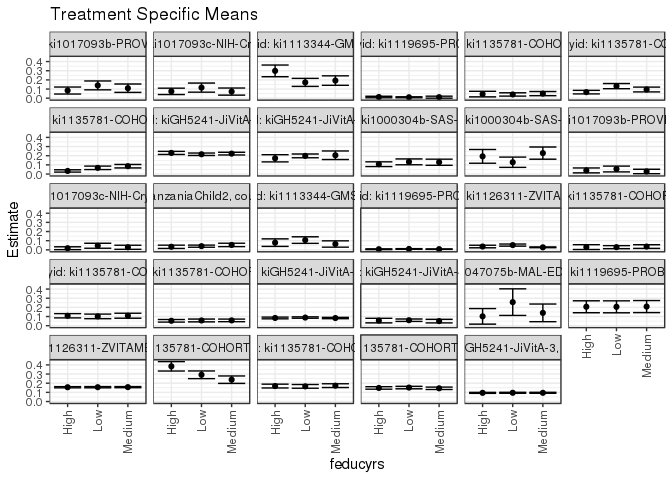

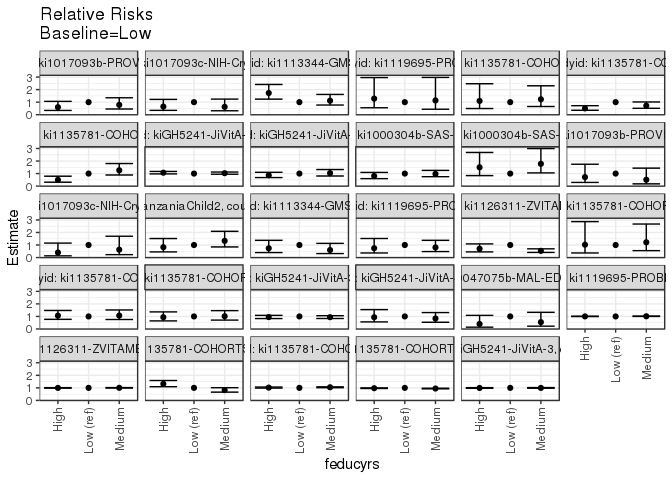

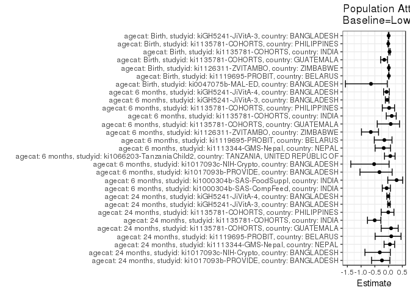

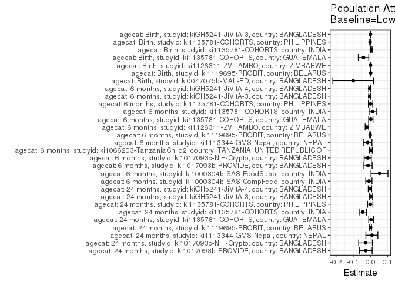

## Results Table

### Parameter: TSM

| agecat | studyid | country | intervention_level | baseline_level | estimate | ci_lower | ci_upper |
| --- | --- | --- | --- | --- | --- | --- | --- |
| Birth | ki0047075b-MAL-ED | BANGLADESH | Low | NA | 0.2571429 | 0.1118044 | 0.4024813 |
| Birth | ki0047075b-MAL-ED | BANGLADESH | Medium | NA | 0.1400000 | 0.0434610 | 0.2365390 |
| Birth | ki0047075b-MAL-ED | BANGLADESH | High | NA | 0.1020408 | 0.0169678 | 0.1871138 |
| Birth | ki1119695-PROBIT | BELARUS | Low | NA | 0.2061080 | 0.1407667 | 0.2714493 |
| Birth | ki1119695-PROBIT | BELARUS | Medium | NA | 0.2086347 | 0.1429531 | 0.2743163 |
| Birth | ki1119695-PROBIT | BELARUS | High | NA | 0.2067427 | 0.1415525 | 0.2719330 |
| Birth | ki1126311-ZVITAMBO | ZIMBABWE | Low | NA | 0.1564508 | 0.1497952 | 0.1631064 |
| Birth | ki1126311-ZVITAMBO | ZIMBABWE | Medium | NA | 0.1571690 | 0.1507929 | 0.1635451 |
| Birth | ki1126311-ZVITAMBO | ZIMBABWE | High | NA | 0.1560519 | 0.1493319 | 0.1627718 |
| Birth | ki1135781-COHORTS | GUATEMALA | Low | NA | 0.2918632 | 0.2501647 | 0.3335616 |
| Birth | ki1135781-COHORTS | GUATEMALA | Medium | NA | 0.2385635 | 0.1979477 | 0.2791792 |
| Birth | ki1135781-COHORTS | GUATEMALA | High | NA | 0.3844014 | 0.3330666 | 0.4357362 |
| Birth | ki1135781-COHORTS | INDIA | Low | NA | 0.1654259 | 0.1450922 | 0.1857596 |
| Birth | ki1135781-COHORTS | INDIA | Medium | NA | 0.1734348 | 0.1527632 | 0.1941063 |
| Birth | ki1135781-COHORTS | INDIA | High | NA | 0.1689088 | 0.1481468 | 0.1896709 |
| Birth | ki1135781-COHORTS | PHILIPPINES | Low | NA | 0.1523492 | 0.1388529 | 0.1658455 |
| Birth | ki1135781-COHORTS | PHILIPPINES | Medium | NA | 0.1443782 | 0.1311519 | 0.1576045 |
| Birth | ki1135781-COHORTS | PHILIPPINES | High | NA | 0.1483549 | 0.1349837 | 0.1617260 |
| Birth | kiGH5241-JiVitA-3 | BANGLADESH | Low | NA | 0.0954188 | 0.0899618 | 0.1008759 |
| Birth | kiGH5241-JiVitA-3 | BANGLADESH | Medium | NA | 0.0950443 | 0.0895522 | 0.1005365 |
| Birth | kiGH5241-JiVitA-3 | BANGLADESH | High | NA | 0.0947436 | 0.0892937 | 0.1001934 |
| 6 months | ki1000304b-SAS-CompFeed | INDIA | Low | NA | 0.1328564 | 0.1009635 | 0.1647494 |
| 6 months | ki1000304b-SAS-CompFeed | INDIA | Medium | NA | 0.1289079 | 0.0953940 | 0.1624218 |
| 6 months | ki1000304b-SAS-CompFeed | INDIA | High | NA | 0.1072733 | 0.0813500 | 0.1331966 |
| 6 months | ki1000304b-SAS-FoodSuppl | INDIA | Low | NA | 0.1286855 | 0.0725731 | 0.1847979 |
| 6 months | ki1000304b-SAS-FoodSuppl | INDIA | Medium | NA | 0.2285706 | 0.1619090 | 0.2952322 |
| 6 months | ki1000304b-SAS-FoodSuppl | INDIA | High | NA | 0.1929630 | 0.1180982 | 0.2678279 |
| 6 months | ki1017093b-PROVIDE | BANGLADESH | Low | NA | 0.0550000 | 0.0233769 | 0.0866231 |
| 6 months | ki1017093b-PROVIDE | BANGLADESH | Medium | NA | 0.0279330 | 0.0037727 | 0.0520932 |
| 6 months | ki1017093b-PROVIDE | BANGLADESH | High | NA | 0.0394089 | 0.0126209 | 0.0661968 |

[output cut: 57 more lines]

### Parameter: E(Y)

| agecat | studyid | country | intervention_level | baseline_level | estimate | ci_lower | ci_upper |
| --- | --- | --- | --- | --- | --- | --- | --- |
| Birth | ki0047075b-MAL-ED | BANGLADESH | NA | NA | 0.1567164 | 0.0949338 | 0.2184990 |
| Birth | ki1119695-PROBIT | BELARUS | NA | NA | 0.2079497 | 0.1424160 | 0.2734834 |
| Birth | ki1126311-ZVITAMBO | ZIMBABWE | NA | NA | 0.1577315 | 0.1513599 | 0.1641031 |
| Birth | ki1135781-COHORTS | GUATEMALA | NA | NA | 0.2520891 | 0.2203065 | 0.2838718 |
| Birth | ki1135781-COHORTS | INDIA | NA | NA | 0.1711851 | 0.1506302 | 0.1917400 |
| Birth | ki1135781-COHORTS | PHILIPPINES | NA | NA | 0.1506598 | 0.1372339 | 0.1640858 |
| Birth | kiGH5241-JiVitA-3 | BANGLADESH | NA | NA | 0.0956568 | 0.0903208 | 0.1009928 |
| 6 months | ki1000304b-SAS-CompFeed | INDIA | NA | NA | 0.1239669 | 0.0988748 | 0.1490591 |
| 6 months | ki1000304b-SAS-FoodSuppl | INDIA | NA | NA | 0.1815789 | 0.1427684 | 0.2203895 |
| 6 months | ki1017093b-PROVIDE | BANGLADESH | NA | NA | 0.0412371 | 0.0250690 | 0.0574052 |
| 6 months | ki1017093c-NIH-Crypto | BANGLADESH | NA | NA | 0.0293706 | 0.0169860 | 0.0417552 |
| 6 months | ki1066203-TanzaniaChild2 | TANZANIA, UNITED REPUBLIC OF | NA | NA | 0.0431334 | 0.0342652 | 0.0520016 |
| 6 months | ki1113344-GMS-Nepal | NEPAL | NA | NA | 0.0907473 | 0.0669775 | 0.1145172 |
| 6 months | ki1119695-PROBIT | BELARUS | NA | NA | 0.0084172 | 0.0066782 | 0.0101561 |
| 6 months | ki1126311-ZVITAMBO | ZIMBABWE | NA | NA | 0.0316235 | 0.0277962 | 0.0354508 |
| 6 months | ki1135781-COHORTS | GUATEMALA | NA | NA | 0.0320442 | 0.0205636 | 0.0435248 |
| 6 months | ki1135781-COHORTS | INDIA | NA | NA | 0.1148014 | 0.0980067 | 0.1315962 |
| 6 months | ki1135781-COHORTS | PHILIPPINES | NA | NA | 0.0581577 | 0.0490934 | 0.0672220 |
| 6 months | kiGH5241-JiVitA-3 | BANGLADESH | NA | NA | 0.0845872 | 0.0796525 | 0.0895218 |
| 6 months | kiGH5241-JiVitA-4 | BANGLADESH | NA | NA | 0.0556693 | 0.0447722 | 0.0665664 |
| 24 months | ki1017093b-PROVIDE | BANGLADESH | NA | NA | 0.1124567 | 0.0866788 | 0.1382347 |
| 24 months | ki1017093c-NIH-Crypto | BANGLADESH | NA | NA | 0.0875486 | 0.0630907 | 0.1120065 |
| 24 months | ki1113344-GMS-Nepal | NEPAL | NA | NA | 0.1810865 | 0.1471967 | 0.2149763 |
| 24 months | ki1119695-PROBIT | BELARUS | NA | NA | 0.0111630 | 0.0050745 | 0.0172515 |
| 24 months | ki1135781-COHORTS | GUATEMALA | NA | NA | 0.0449102 | 0.0320802 | 0.0577401 |
| 24 months | ki1135781-COHORTS | INDIA | NA | NA | 0.0875912 | 0.0726161 | 0.1025664 |
| 24 months | ki1135781-COHORTS | PHILIPPINES | NA | NA | 0.0668392 | 0.0566723 | 0.0770060 |
| 24 months | kiGH5241-JiVitA-3 | BANGLADESH | NA | NA | 0.2190286 | 0.2088944 | 0.2291627 |
| 24 months | kiGH5241-JiVitA-4 | BANGLADESH | NA | NA | 0.1958763 | 0.1777261 | 0.2140265 |

### Parameter: RR

| agecat | studyid | country | intervention_level | baseline_level | estimate | ci_lower | ci_upper |
| --- | --- | --- | --- | --- | --- | --- | --- |
| Birth | ki0047075b-MAL-ED | BANGLADESH | Low | Low | 1.0000000 | 1.0000000 | 1.0000000 |
| Birth | ki0047075b-MAL-ED | BANGLADESH | Medium | Low | 0.5444444 | 0.2232211 | 1.3279198 |
| Birth | ki0047075b-MAL-ED | BANGLADESH | High | Low | 0.3968254 | 0.1449304 | 1.0865246 |
| Birth | ki1119695-PROBIT | BELARUS | Low | Low | 1.0000000 | 1.0000000 | 1.0000000 |
| Birth | ki1119695-PROBIT | BELARUS | Medium | Low | 1.0122589 | 0.9994596 | 1.0252220 |
| Birth | ki1119695-PROBIT | BELARUS | High | Low | 1.0030796 | 0.9915978 | 1.0146942 |
| Birth | ki1126311-ZVITAMBO | ZIMBABWE | Low | Low | 1.0000000 | 1.0000000 | 1.0000000 |
| Birth | ki1126311-ZVITAMBO | ZIMBABWE | Medium | Low | 1.0045903 | 0.9886715 | 1.0207653 |
| Birth | ki1126311-ZVITAMBO | ZIMBABWE | High | Low | 0.9974502 | 0.9762600 | 1.0191004 |
| Birth | ki1135781-COHORTS | GUATEMALA | Low | Low | 1.0000000 | 1.0000000 | 1.0000000 |
| Birth | ki1135781-COHORTS | GUATEMALA | Medium | Low | 0.8173812 | 0.6599271 | 1.0124027 |
| Birth | ki1135781-COHORTS | GUATEMALA | High | Low | 1.3170603 | 1.0919959 | 1.5885113 |
| Birth | ki1135781-COHORTS | INDIA | Low | Low | 1.0000000 | 1.0000000 | 1.0000000 |
| Birth | ki1135781-COHORTS | INDIA | Medium | Low | 1.0484139 | 1.0148291 | 1.0831101 |
| Birth | ki1135781-COHORTS | INDIA | High | Low | 1.0210545 | 0.9805018 | 1.0632844 |
| Birth | ki1135781-COHORTS | PHILIPPINES | Low | Low | 1.0000000 | 1.0000000 | 1.0000000 |
| Birth | ki1135781-COHORTS | PHILIPPINES | Medium | Low | 0.9476797 | 0.9233058 | 0.9726969 |
| Birth | ki1135781-COHORTS | PHILIPPINES | High | Low | 0.9737818 | 0.9524877 | 0.9955520 |
| Birth | kiGH5241-JiVitA-3 | BANGLADESH | Low | Low | 1.0000000 | 1.0000000 | 1.0000000 |
| Birth | kiGH5241-JiVitA-3 | BANGLADESH | Medium | Low | 0.9960750 | 0.9715711 | 1.0211970 |
| Birth | kiGH5241-JiVitA-3 | BANGLADESH | High | Low | 0.9929229 | 0.9681124 | 1.0183693 |
| 6 months | ki1000304b-SAS-CompFeed | INDIA | Low | Low | 1.0000000 | 1.0000000 | 1.0000000 |
| 6 months | ki1000304b-SAS-CompFeed | INDIA | Medium | Low | 0.9702796 | 0.7511217 | 1.2533822 |
| 6 months | ki1000304b-SAS-CompFeed | INDIA | High | Low | 0.8074380 | 0.5981952 | 1.0898719 |
| 6 months | ki1000304b-SAS-FoodSuppl | INDIA | Low | Low | 1.0000000 | 1.0000000 | 1.0000000 |
| 6 months | ki1000304b-SAS-FoodSuppl | INDIA | Medium | Low | 1.7761961 | 1.0527088 | 2.9969092 |
| 6 months | ki1000304b-SAS-FoodSuppl | INDIA | High | Low | 1.4994936 | 0.8378258 | 2.6837096 |
| 6 months | ki1017093b-PROVIDE | BANGLADESH | Low | Low | 1.0000000 | 1.0000000 | 1.0000000 |
| 6 months | ki1017093b-PROVIDE | BANGLADESH | Medium | Low | 0.5078720 | 0.1797603 | 1.4348774 |
| 6 months | ki1017093b-PROVIDE | BANGLADESH | High | Low | 0.7165249 | 0.2941563 | 1.7453574 |

[output cut: 57 more lines]

### Parameter: PAR

| agecat | studyid | country | intervention_level | baseline_level | estimate | ci_lower | ci_upper |
| --- | --- | --- | --- | --- | --- | --- | --- |
| Birth | ki0047075b-MAL-ED | BANGLADESH | Low | NA | -0.1004264 | -0.2183494 | 0.0174965 |
| Birth | ki1119695-PROBIT | BELARUS | Low | NA | 0.0018417 | 0.0002602 | 0.0034231 |
| Birth | ki1126311-ZVITAMBO | ZIMBABWE | Low | NA | 0.0012807 | -0.0008629 | 0.0034242 |
| Birth | ki1135781-COHORTS | GUATEMALA | Low | NA | -0.0397740 | -0.0701421 | -0.0094060 |
| Birth | ki1135781-COHORTS | INDIA | Low | NA | 0.0057593 | 0.0016609 | 0.0098576 |
| Birth | ki1135781-COHORTS | PHILIPPINES | Low | NA | -0.0016894 | -0.0038731 | 0.0004943 |
| Birth | kiGH5241-JiVitA-3 | BANGLADESH | Low | NA | 0.0002379 | -0.0009483 | 0.0014242 |
| 6 months | ki1000304b-SAS-CompFeed | INDIA | Low | NA | -0.0088895 | -0.0271550 | 0.0093761 |
| 6 months | ki1000304b-SAS-FoodSuppl | INDIA | Low | NA | 0.0528935 | 0.0037511 | 0.1020359 |
| 6 months | ki1017093b-PROVIDE | BANGLADESH | Low | NA | -0.0137629 | -0.0377239 | 0.0101981 |
| 6 months | ki1017093c-NIH-Crypto | BANGLADESH | Low | NA | -0.0154724 | -0.0362416 | 0.0052968 |
| 6 months | ki1066203-TanzaniaChild2 | TANZANIA, UNITED REPUBLIC OF | Low | NA | 0.0026982 | -0.0055457 | 0.0109422 |
| 6 months | ki1113344-GMS-Nepal | NEPAL | Low | NA | -0.0160706 | -0.0412780 | 0.0091368 |
| 6 months | ki1119695-PROBIT | BELARUS | Low | NA | -0.0012966 | -0.0040449 | 0.0014518 |
| 6 months | ki1126311-ZVITAMBO | ZIMBABWE | Low | NA | -0.0204688 | -0.0304243 | -0.0105133 |
| 6 months | ki1135781-COHORTS | GUATEMALA | Low | NA | 0.0024875 | -0.0101507 | 0.0151258 |
| 6 months | ki1135781-COHORTS | INDIA | Low | NA | 0.0131346 | -0.0076685 | 0.0339377 |
| 6 months | ki1135781-COHORTS | PHILIPPINES | Low | NA | 0.0011082 | -0.0117504 | 0.0139667 |
| 6 months | kiGH5241-JiVitA-3 | BANGLADESH | Low | NA | -0.0042376 | -0.0098269 | 0.0013517 |
| 6 months | kiGH5241-JiVitA-4 | BANGLADESH | Low | NA | -0.0040445 | -0.0099448 | 0.0018558 |
| 24 months | ki1017093b-PROVIDE | BANGLADESH | Low | NA | -0.0272012 | -0.0646504 | 0.0102479 |
| 24 months | ki1017093c-NIH-Crypto | BANGLADESH | Low | NA | -0.0281212 | -0.0680486 | 0.0118062 |
| 24 months | ki1113344-GMS-Nepal | NEPAL | Low | NA | 0.0085039 | -0.0262901 | 0.0432978 |
| 24 months | ki1119695-PROBIT | BELARUS | Low | NA | 0.0010824 | -0.0042494 | 0.0064142 |
| 24 months | ki1135781-COHORTS | GUATEMALA | Low | NA | 0.0040500 | -0.0096575 | 0.0177575 |
| 24 months | ki1135781-COHORTS | INDIA | Low | NA | -0.0442539 | -0.0656040 | -0.0229039 |
| 24 months | ki1135781-COHORTS | PHILIPPINES | Low | NA | -0.0007762 | -0.0161584 | 0.0146059 |
| 24 months | kiGH5241-JiVitA-3 | BANGLADESH | Low | NA | 0.0030880 | -0.0067488 | 0.0129249 |
| 24 months | kiGH5241-JiVitA-4 | BANGLADESH | Low | NA | -0.0024023 | -0.0124488 | 0.0076442 |

### Parameter: PAF

| agecat | studyid | country | intervention_level | baseline_level | estimate | ci_lower | ci_upper |
| --- | --- | --- | --- | --- | --- | --- | --- |
| Birth | ki0047075b-MAL-ED | BANGLADESH | Low | NA | -0.6408163 | -1.5691781 | -0.0479142 |
| Birth | ki1119695-PROBIT | BELARUS | Low | NA | 0.0088564 | 0.0010830 | 0.0165694 |
| Birth | ki1126311-ZVITAMBO | ZIMBABWE | Low | NA | 0.0081192 | -0.0055572 | 0.0216096 |
| Birth | ki1135781-COHORTS | GUATEMALA | Low | NA | -0.1577777 | -0.2887166 | -0.0401427 |
| Birth | ki1135781-COHORTS | INDIA | Low | NA | 0.0336435 | 0.0096909 | 0.0570168 |
| Birth | ki1135781-COHORTS | PHILIPPINES | Low | NA | -0.0112132 | -0.0258962 | 0.0032597 |
| Birth | kiGH5241-JiVitA-3 | BANGLADESH | Low | NA | 0.0024874 | -0.0099907 | 0.0148113 |
| 6 months | ki1000304b-SAS-CompFeed | INDIA | Low | NA | -0.0717085 | -0.2295003 | 0.0658326 |
| 6 months | ki1000304b-SAS-FoodSuppl | INDIA | Low | NA | 0.2912975 | -0.0302404 | 0.5124834 |
| 6 months | ki1017093b-PROVIDE | BANGLADESH | Low | NA | -0.3337500 | -1.0416461 | 0.1286986 |
| 6 months | ki1017093c-NIH-Crypto | BANGLADESH | Low | NA | -0.5267990 | -1.3752445 | 0.0185788 |
| 6 months | ki1066203-TanzaniaChild2 | TANZANIA, UNITED REPUBLIC OF | Low | NA | 0.0625559 | -0.1489546 | 0.2351296 |
| 6 months | ki1113344-GMS-Nepal | NEPAL | Low | NA | -0.1770920 | -0.4913569 | 0.0709497 |
| 6 months | ki1119695-PROBIT | BELARUS | Low | NA | -0.1540378 | -0.5203777 | 0.1240314 |
| 6 months | ki1126311-ZVITAMBO | ZIMBABWE | Low | NA | -0.6472655 | -0.9865611 | -0.3659200 |
| 6 months | ki1135781-COHORTS | GUATEMALA | Low | NA | 0.0776287 | -0.4131012 | 0.3979420 |
| 6 months | ki1135781-COHORTS | INDIA | Low | NA | 0.1144115 | -0.0849107 | 0.2771138 |
| 6 months | ki1135781-COHORTS | PHILIPPINES | Low | NA | 0.0190546 | -0.2287409 | 0.2168781 |
| 6 months | kiGH5241-JiVitA-3 | BANGLADESH | Low | NA | -0.0500977 | -0.1183829 | 0.0140182 |
| 6 months | kiGH5241-JiVitA-4 | BANGLADESH | Low | NA | -0.0726529 | -0.1817934 | 0.0264082 |
| 24 months | ki1017093b-PROVIDE | BANGLADESH | Low | NA | -0.2418817 | -0.6191157 | 0.0474614 |
| 24 months | ki1017093c-NIH-Crypto | BANGLADESH | Low | NA | -0.3212064 | -0.8609197 | 0.0619765 |
| 24 months | ki1113344-GMS-Nepal | NEPAL | Low | NA | 0.0469603 | -0.1641914 | 0.2198149 |
| 24 months | ki1119695-PROBIT | BELARUS | Low | NA | 0.0969617 | -0.4895867 | 0.4525474 |
| 24 months | ki1135781-COHORTS | GUATEMALA | Low | NA | 0.0901792 | -0.2710851 | 0.3487660 |
| 24 months | ki1135781-COHORTS | INDIA | Low | NA | -0.5052326 | -0.7684756 | -0.2811741 |
| 24 months | ki1135781-COHORTS | PHILIPPINES | Low | NA | -0.0116136 | -0.2699667 | 0.1941820 |
| 24 months | kiGH5241-JiVitA-3 | BANGLADESH | Low | NA | 0.0140987 | -0.0317747 | 0.0579325 |
| 24 months | kiGH5241-JiVitA-4 | BANGLADESH | Low | NA | -0.0122645 | -0.0649239 | 0.0377910 |